# 09_analysis_lm_alcohol

Authors

Asta Zeuner - s203544 - azeuner

Astrid Ginnerup - s203523 - AGinnerup

Emma Danø - s203564 - EDanoe

Andrea Kristensen - s193769 - AndreaMTK

Yayi Wang - s243554 - Yayi0117

## Load libraries

```r
library("tidyverse")
library("broom")
library("ggthemes")
library("ggrepel")
library("here")
```

## Loading data

```r
expression_meta_data_aug <- read_tsv(file = here("data/03_expression_meta_data_aug.tsv.gz"))
```

# Linear model: alcohol history

## Selecting variables, grouping and nesting the data for the linear modelling

Selecting the variables that we want to use for the linear modeling. NA’s in “expression” are dropped.

```r
expression_meta_data_lm_alcohol <- expression_meta_data_aug |>
  select(alcohol_history_binomial,
         peptide_target,
         expression) |>
   drop_na(expression)

expression_meta_data_lm_alcohol
```

```
# A tibble: 161,195 × 3
   alcohol_history_binomial peptide_target expression
                      <dbl> <chr>               <dbl>
 1                        0 1433BETA          -0.0974
 2                        0 1433EPSILON       -0.0884
 3                        0 1433ZETA           0.295
 4                        0 4EBP1              0.236
 5                        0 4EBP1_pS65        -0.332
 6                        0 4EBP1_pT37T46     -0.209
 7                        0 4EBP1_pT70        -0.0246
 8                        0 53BP1             -0.644
 9                        0 ACC_pS79          -0.590
10                        0 ACC1              -0.119
# ℹ 161,185 more rows
```

```r
expression_meta_data_lm_alcohol_nested <- expression_meta_data_lm_alcohol |>
  group_by(peptide_target) |>
  nest()

expression_meta_data_lm_alcohol_nested
```

```
# A tibble: 469 × 2
# Groups:   peptide_target [469]
   peptide_target data
   <chr>          <list>
 1 1433BETA       <tibble [353 × 2]>
 2 1433EPSILON    <tibble [353 × 2]>
 3 1433ZETA       <tibble [353 × 2]>
 4 4EBP1          <tibble [353 × 2]>
 5 4EBP1_pS65     <tibble [353 × 2]>
 6 4EBP1_pT37T46  <tibble [353 × 2]>
 7 4EBP1_pT70     <tibble [353 × 2]>
 8 53BP1          <tibble [353 × 2]>
 9 ACC_pS79       <tibble [353 × 2]>
10 ACC1           <tibble [353 × 2]>
# ℹ 459 more rows
```

## Adding the linear model to the dataset

Adding the linear model to the data using mutate().

```r
expression_meta_data_lm_alcohol_nested_model <- expression_meta_data_lm_alcohol_nested |>
  mutate(model_object = map(.x = data,
                            .f = ~lm(formula = expression ~ alcohol_history_binomial,
                                   data = .x)))

expression_meta_data_lm_alcohol_nested_model
```

```
# A tibble: 469 × 3
# Groups:   peptide_target [469]
   peptide_target data               model_object
   <chr>          <list>             <list>
 1 1433BETA       <tibble [353 × 2]> <lm>
 2 1433EPSILON    <tibble [353 × 2]> <lm>
 3 1433ZETA       <tibble [353 × 2]> <lm>
 4 4EBP1          <tibble [353 × 2]> <lm>
 5 4EBP1_pS65     <tibble [353 × 2]> <lm>
 6 4EBP1_pT37T46  <tibble [353 × 2]> <lm>
 7 4EBP1_pT70     <tibble [353 × 2]> <lm>
 8 53BP1          <tibble [353 × 2]> <lm>
 9 ACC_pS79       <tibble [353 × 2]> <lm>
10 ACC1           <tibble [353 × 2]> <lm>
# ℹ 459 more rows
```

Computing the confidence intervals and p-value using tidy()

```r
expression_meta_data_lm_alcohol_nested_model_tidy <- expression_meta_data_lm_alcohol_nested_model |>
  mutate(model_object_tidy = map(.x = model_object,
                                 .f = ~ tidy(conf.int = TRUE,
                                             conf.level = 0.95,
                                             x =.x)))

expression_meta_data_lm_alcohol_nested_model_tidy
```

```
# A tibble: 469 × 4
# Groups:   peptide_target [469]
   peptide_target data               model_object model_object_tidy
   <chr>          <list>             <list>       <list>
 1 1433BETA       <tibble [353 × 2]> <lm>         <tibble [2 × 7]>
 2 1433EPSILON    <tibble [353 × 2]> <lm>         <tibble [2 × 7]>
 3 1433ZETA       <tibble [353 × 2]> <lm>         <tibble [2 × 7]>
 4 4EBP1          <tibble [353 × 2]> <lm>         <tibble [2 × 7]>
 5 4EBP1_pS65     <tibble [353 × 2]> <lm>         <tibble [2 × 7]>
 6 4EBP1_pT37T46  <tibble [353 × 2]> <lm>         <tibble [2 × 7]>
 7 4EBP1_pT70     <tibble [353 × 2]> <lm>         <tibble [2 × 7]>
 8 53BP1          <tibble [353 × 2]> <lm>         <tibble [2 × 7]>
 9 ACC_pS79       <tibble [353 × 2]> <lm>         <tibble [2 × 7]>
10 ACC1           <tibble [353 × 2]> <lm>         <tibble [2 × 7]>
# ℹ 459 more rows
```

## Wrangling the expression data estimates

```r
expression_meta_data_lm_alcohol_estimates <- expression_meta_data_lm_alcohol_nested_model_tidy |>
  unnest(model_object_tidy)

expression_meta_data_lm_alcohol_estimates
```

```
# A tibble: 938 × 10
# Groups:   peptide_target [469]
   peptide_target data     model_object term        estimate std.error statistic
   <chr>          <list>   <list>       <chr>          <dbl>     <dbl>     <dbl>
 1 1433BETA       <tibble> <lm>         (Intercept)  2.11e-2    0.0114    1.84
 2 1433BETA       <tibble> <lm>         alcohol_hi…  1.04e-2    0.0146    0.714
 3 1433EPSILON    <tibble> <lm>         (Intercept)  7.69e-2    0.0190    4.06
 4 1433EPSILON    <tibble> <lm>         alcohol_hi…  8.19e-3    0.0242    0.339
 5 1433ZETA       <tibble> <lm>         (Intercept)  5.48e-1    0.0428   12.8
 6 1433ZETA       <tibble> <lm>         alcohol_hi… -8.41e-4    0.0545   -0.0154
 7 4EBP1          <tibble> <lm>         (Intercept)  5.09e-1    0.0469   10.8
 8 4EBP1          <tibble> <lm>         alcohol_hi… -1.03e-1    0.0598   -1.72
 9 4EBP1_pS65     <tibble> <lm>         (Intercept) -1.61e-1    0.0272   -5.91
10 4EBP1_pS65     <tibble> <lm>         alcohol_hi… -1.77e-2    0.0347   -0.511
# ℹ 928 more rows
# ℹ 3 more variables: p.value <dbl>, conf.low <dbl>, conf.high <dbl>
```

## Clean the data and calculating q.value

Term describes if the patient drinks alcohol. 0 = no and 1 = yes. Therefore the intercept the patient does not drink alcohol and the slope + intercept the patient does drink alcohol.

```r
expression_meta_data_lm_alcohol_estimates_clean <- expression_meta_data_lm_alcohol_estimates |>
  filter(term == "alcohol_history_binomial") |>
  select(peptide_target,
         p.value,
         estimate,
         conf.low,
         conf.high) |>
  ungroup(peptide_target)

expression_meta_data_lm_alcohol_estimates_clean
```

```
# A tibble: 469 × 5
   peptide_target p.value  estimate conf.low conf.high
   <chr>            <dbl>     <dbl>    <dbl>     <dbl>
 1 1433BETA       0.476    0.0104    -0.0183    0.0391
 2 1433EPSILON    0.735    0.00819   -0.0393    0.0557
 3 1433ZETA       0.988   -0.000841  -0.108     0.106
 4 4EBP1          0.0859  -0.103     -0.221     0.0146
 5 4EBP1_pS65     0.610   -0.0177    -0.0860    0.0506
 6 4EBP1_pT37T46  0.00416 -0.209     -0.352    -0.0666
 7 4EBP1_pT70     0.389   -0.0257    -0.0842    0.0328
 8 53BP1          0.548    0.0353    -0.0800    0.151
 9 ACC_pS79       0.130   -0.0683    -0.157     0.0203
10 ACC1           0.275   -0.0646    -0.181     0.0516
# ℹ 459 more rows
```

Adding the adjusted p-value in a new variable, q.value, and add extra variable that tells if the q-value is significant or not with alpha = 5%

```r
expression_meta_data_lm_alcohol_estimates_clean <- expression_meta_data_lm_alcohol_estimates_clean |>
  mutate(q.value = p.adjust(p = p.value),
         is_significant = case_when(q.value > 0.05 ~ "no",
                                    q.value <= 0.05 ~ "yes"),
         label = case_when(is_significant == "yes" ~ peptide_target,
                           is_significant == "no" ~ ""))

expression_meta_data_lm_alcohol_estimates_clean
```

```
# A tibble: 469 × 8
   peptide_target p.value  estimate conf.low conf.high q.value is_significant
   <chr>            <dbl>     <dbl>    <dbl>     <dbl>   <dbl> <chr>
 1 1433BETA       0.476    0.0104    -0.0183    0.0391       1 no
 2 1433EPSILON    0.735    0.00819   -0.0393    0.0557       1 no
 3 1433ZETA       0.988   -0.000841  -0.108     0.106        1 no
 4 4EBP1          0.0859  -0.103     -0.221     0.0146       1 no
 5 4EBP1_pS65     0.610   -0.0177    -0.0860    0.0506       1 no
 6 4EBP1_pT37T46  0.00416 -0.209     -0.352    -0.0666       1 no
 7 4EBP1_pT70     0.389   -0.0257    -0.0842    0.0328       1 no
 8 53BP1          0.548    0.0353    -0.0800    0.151        1 no
 9 ACC_pS79       0.130   -0.0683    -0.157     0.0203       1 no
10 ACC1           0.275   -0.0646    -0.181     0.0516       1 no
# ℹ 459 more rows
# ℹ 1 more variable: label <chr>
```

```r
expression_meta_data_lm_alcohol_estimates_clean |>
  filter(is_significant == "yes")
```

```
# A tibble: 1 × 8
  peptide_target   p.value estimate conf.low conf.high q.value is_significant
  <chr>              <dbl>    <dbl>    <dbl>     <dbl>   <dbl> <chr>
1 ANNEXINVII     0.0000880    0.109   0.0549     0.163  0.0413 yes
# ℹ 1 more variable: label <chr>
```

We have 1 protein where the expression levels are found to be significantly different between patients that drink alcohol and patients that does not.

## Volcano plot

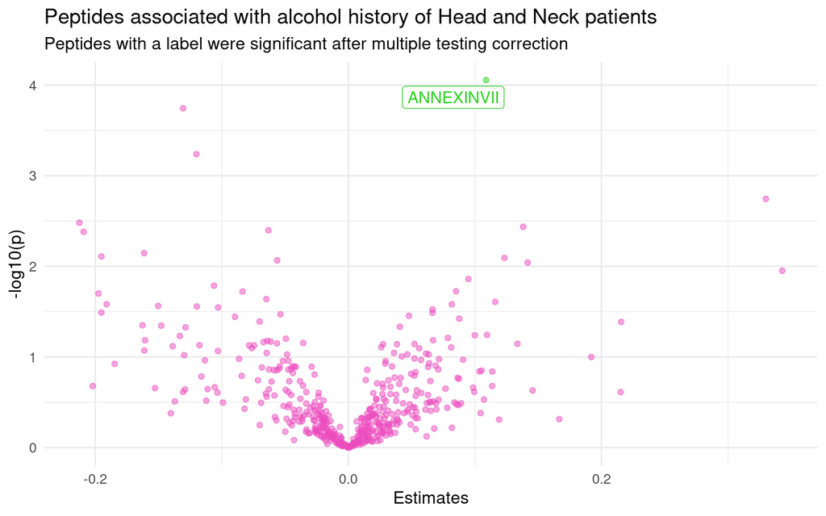

```r
volcano_plot_alcohol <- expression_meta_data_lm_alcohol_estimates_clean |>
  ggplot(mapping = aes(x = estimate,
                       y = -log10(p.value),
                       color = is_significant)) +
  geom_point(alpha = 0.5) +
  scale_color_manual(values = c("yes" =  "#2bd11f",
                                "no" ="#eb4cbe")) +
  geom_label_repel(aes(label = label),
                   size = 4,
                   max.overlaps = 25) +
  labs(title = "Peptides associated with alcohol history of Head and Neck patients",
       subtitle = "Peptides with a label were significant after multiple testing correction",
       x = "Estimates",
       y = "-log10(p)") +
  theme_minimal(base_size = 12) +
  theme(plot.title = element_text(hjust = 0),
        plot.subtitle = element_text(hjust = 0),
        legend.position = "none")

volcano_plot_alcohol
```

```r
ggsave(filename = "09_analysis_lm_volcano_alcohol.png",
       plot = volcano_plot_alcohol,
       device = "png",
       path = "../results/images")
```